## Machine Learning Project Assignment

## Weight lifting exercise - Predict if exercises are done correctly

**Background** Using devices such as Jawbone Up, Nike FuelBand, and Fitbit it is now possible to collect a large amount of data about personal activity relatively inexpensively. These type of devices are part of the quantified self movement - a group of enthusiasts who take measurements about themselves regularly to improve their health, to find patterns in their behavior, or because they are tech geeks. One thing that people regularly do is quantify how much of a particular activity they do, but they rarely quantify how well they do it. In this project, your goal will be to use data from accelerometers on the belt, forearm, arm, and dumbell of 6 participants. They were asked to perform barbell lifts correctly and incorrectly in 5 different ways. More information is available from the website here: http://groupware.les.inf.puc-rio.br/har (see the section on the Weight Lifting Exercise Dataset).

The training data for this project are available here:

https://d396qusza40orc.cloudfront.net/predmachlearn/pml-training.csv

The test data are available here:

https://d396qusza40orc.cloudfront.net/predmachlearn/pml-testing.csv

**Reference** Ugulino, W.; Cardador, D.; Vega, K.; Velloso, E.; Milidiu, R.; Fuks, H. Wearable Computing: Accelerometers’ Data Classification of Body Postures and Movements. Proceedings of 21st Brazilian Symposium on Artificial Intelligence. Advances in Artificial Intelligence - SBIA 2012. In: Lecture Notes in Computer Science. pp. 52-61. Curitiba, PR: Springer Berlin / Heidelberg, 2012. ISBN 978-3-642-34458-9. DOI: 10.1007/978-3-642-34459-6_6. http://groupware.les.inf.puc-rio.br/work.jsf?p1=10335

**Objective** Develop a prediction model using the training data set to predict Classe.

**Summary** A prediction model was developed based on random forest which did very well in cross validation and was able to classify all testing observations (20) correctly

**Loading & Exploring Data**

```r
# Loading libraries & enable parallel processing
library(caret);library(gbm);library(randomForest);library(doParallel)
set.seed(12345)
cl <- makeCluster(detectCores());registerDoParallel(cl)
```

```r
training.rd <- read.csv("C:/Users/Werner/Documents/rcourse/pml01/pmldata/pml-training.csv")
testing.rd <- read.csv("C:/Users/Werner/Documents/rcourse/pml01/pmldata/pml-testing.csv")
```

```r
dim(training.rd);dim(testing.rd);
```

```
## [1] 19622   160
```

```
## [1]  20 160
```

With 19622 rows and 160 columns the training data set is huge. Using commands like View(training.rd) and edit(training.rd) the need for cleaning data is obvious (empty columns, NA columns). Also columns 1 to 7 are not related to measurements. Not related columns and NA columns are eliminated. In case I have trouble to develop a very predictive model I would come back to the data cleaning activities. As the number of columns is huge I also use nearZeroVar(t) to eliminate columns with small variances (no or small predictive value)

```r
t<- training.rd[,!sapply(training.rd,function(x) any(is.na(x)))]
t <- t[,-c(1:7)]
nvar <- nearZeroVar(t)
tm <-  t[,-nvar]; dim(tm)
```

```
## [1] 19622    53
```

**Test & Validation Data** The 19622 rows are splitted. 13737 rows are used to develop the model, 5885 rows are kept aside to validate the model(s)

```r
# create training set indexes with 70% of data
inTrain <- createDataPartition(y=tm$classe,p=0.70, list=FALSE)
training.dt <- tm[inTrain,]
val.dt <- tm[-inTrain,]
dim(training.dt); dim(val.dt)
```

```
## [1] 13737    53
```

```
## [1] 5885   53
```

**Model Development** As we have a classification problem (5 classes) a very popular and accurate method is random forest tree (RF) along with boosting. The 2nd method is therefore is gradient boosted Regression Model (GBM). As RF showed very accurate prediction with default values it was the model of choice. I tried to improve the default RF model but was not able to improve it with mtry.

- Model 1 (f1) : Random Forest, default setting
- Model 2 (f2) : Generalized Boosted Regression Modeling
- Model 3 (f3) : Random Forest, with optimal mtry parameter

```r
tuneRF(training.dt[,-53], training.dt[,53])
```

```
## mtry = 7  OOB error = 0.85%
## Searching left ...
## mtry = 4     OOB error = 0.94%
## -0.1025641 0.05
## Searching right ...
## mtry = 14    OOB error = 0.9%
## -0.05982906 0.05
```

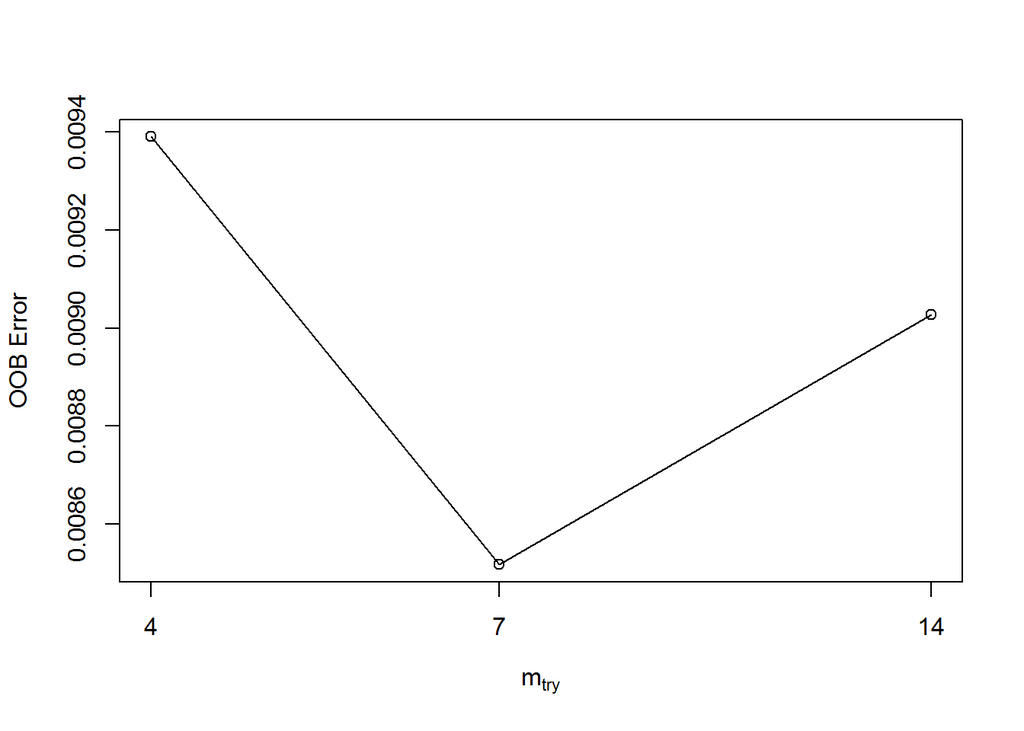

```
##        mtry    OOBError
## 4.OOB     4 0.009390697
## 7.OOB     7 0.008517143
## 14.OOB   14 0.009026716
```

```r
f1 <- randomForest(classe ~ ., data = training.dt)
f2 <- train(classe ~ ., data = training.dt,method="gbm",verbose=FALSE)
f3 <- randomForest(classe ~ ., data = training.dt, mtry=7)
```

**Model Validation** The 3 models are tested against the training data set and validated against the validation training set

```r
pred.t1 <- predict(f1, training.dt)
c.t1<- confusionMatrix(training.dt$classe,pred.t1)

pred.t2 <- predict(f2, training.dt)
c.t2<- confusionMatrix(training.dt$classe,pred.t2)

pred.t3 <- pred.t3 <- predict(f3, training.dt)
c.t3 <- confusionMatrix(training.dt$classe,pred.t3)

pred.v1 <- predict(f1, val.dt)
c.v1 <- confusionMatrix(val.dt$classe,pred.v1)

pred.v2 <- predict(f2, val.dt)
c.v2<- confusionMatrix(val.dt$classe,pred.v2)

pred.v3 <- predict(f3, val.dt)
c.v3 <- confusionMatrix(val.dt$classe,pred.v3)
```

**Print Confusion Matrix for Training Data Set**

```r
c.t1; c.t2;c.t3
```

```
## Confusion Matrix and Statistics
##
##           Reference
## Prediction    A    B    C    D    E
##          A 3906    0    0    0    0
##          B    0 2658    0    0    0
##          C    0    0 2396    0    0
##          D    0    0    0 2252    0
##          E    0    0    0    0 2525
##
## Overall Statistics
##
##                Accuracy : 1
##                  95% CI : (0.9997, 1)
##     No Information Rate : 0.2843
##     P-Value [Acc > NIR] : < 2.2e-16
##
##                   Kappa : 1
##  Mcnemar's Test P-Value : NA
##
## Statistics by Class:
##
##                      Class: A Class: B Class: C Class: D Class: E
## Sensitivity            1.0000   1.0000   1.0000   1.0000   1.0000
## Specificity            1.0000   1.0000   1.0000   1.0000   1.0000
## Pos Pred Value         1.0000   1.0000   1.0000   1.0000   1.0000
## Neg Pred Value         1.0000   1.0000   1.0000   1.0000   1.0000
## Prevalence             0.2843   0.1935   0.1744   0.1639   0.1838
## Detection Rate         0.2843   0.1935   0.1744   0.1639   0.1838
## Detection Prevalence   0.2843   0.1935   0.1744   0.1639   0.1838
## Balanced Accuracy      1.0000   1.0000   1.0000   1.0000   1.0000
```

```
## Confusion Matrix and Statistics
##
##           Reference
## Prediction    A    B    C    D    E
##          A 3866   25   11    3    1
##          B   57 2553   47    0    1
##          C    0   51 2322   19    4
##          D    2    2   69 2173    6
##          E    2   10   14   28 2471
##
## Overall Statistics
##
##                Accuracy : 0.9744
##                  95% CI : (0.9716, 0.977)
##     No Information Rate : 0.2859
##     P-Value [Acc > NIR] : < 2.2e-16
##
##                   Kappa : 0.9676
##  Mcnemar's Test P-Value : 2.279e-13
##
## Statistics by Class:
##
##                      Class: A Class: B Class: C Class: D Class: E
## Sensitivity            0.9845   0.9667   0.9428   0.9775   0.9952
## Specificity            0.9959   0.9905   0.9934   0.9931   0.9952
## Pos Pred Value         0.9898   0.9605   0.9691   0.9649   0.9786
## Neg Pred Value         0.9938   0.9921   0.9876   0.9956   0.9989
## Prevalence             0.2859   0.1923   0.1793   0.1618   0.1808
## Detection Rate         0.2814   0.1858   0.1690   0.1582   0.1799
## Detection Prevalence   0.2843   0.1935   0.1744   0.1639   0.1838
## Balanced Accuracy      0.9902   0.9786   0.9681   0.9853   0.9952
```

```
## Confusion Matrix and Statistics
##
##           Reference
## Prediction    A    B    C    D    E
##          A 3906    0    0    0    0
##          B    0 2658    0    0    0
##          C    0    0 2396    0    0
##          D    0    0    0 2252    0
##          E    0    0    0    0 2525
##
## Overall Statistics
##
##                Accuracy : 1
##                  95% CI : (0.9997, 1)
##     No Information Rate : 0.2843
##     P-Value [Acc > NIR] : < 2.2e-16
##
##                   Kappa : 1
##  Mcnemar's Test P-Value : NA
##
## Statistics by Class:
##
##                      Class: A Class: B Class: C Class: D Class: E
## Sensitivity            1.0000   1.0000   1.0000   1.0000   1.0000
## Specificity            1.0000   1.0000   1.0000   1.0000   1.0000
## Pos Pred Value         1.0000   1.0000   1.0000   1.0000   1.0000
## Neg Pred Value         1.0000   1.0000   1.0000   1.0000   1.0000
## Prevalence             0.2843   0.1935   0.1744   0.1639   0.1838
## Detection Rate         0.2843   0.1935   0.1744   0.1639   0.1838
## Detection Prevalence   0.2843   0.1935   0.1744   0.1639   0.1838
## Balanced Accuracy      1.0000   1.0000   1.0000   1.0000   1.0000
```

*In Error Sample Rates** t1 (model 1) had no in-errors, t2 (model 2) had about 2.5% in-errors and t3 (model 3) again had no in-errors

**Print Confusion Matrix for Validation Data Set**

```r
c.v1; c.v2;c.v3
```

```
## Confusion Matrix and Statistics
##
##           Reference
## Prediction    A    B    C    D    E
##          A 1673    1    0    0    0
##          B    6 1130    3    0    0
##          C    0    7 1016    3    0
##          D    0    0   11  952    1
##          E    0    0    0    3 1079
##
## Overall Statistics
##
##                Accuracy : 0.9941
##                  95% CI : (0.9917, 0.9959)
##     No Information Rate : 0.2853
##     P-Value [Acc > NIR] : < 2.2e-16
##
##                   Kappa : 0.9925
##  Mcnemar's Test P-Value : NA
##
## Statistics by Class:
##
##                      Class: A Class: B Class: C Class: D Class: E
## Sensitivity            0.9964   0.9930   0.9864   0.9937   0.9991
## Specificity            0.9998   0.9981   0.9979   0.9976   0.9994
## Pos Pred Value         0.9994   0.9921   0.9903   0.9876   0.9972
## Neg Pred Value         0.9986   0.9983   0.9971   0.9988   0.9998
## Prevalence             0.2853   0.1934   0.1750   0.1628   0.1835
## Detection Rate         0.2843   0.1920   0.1726   0.1618   0.1833
## Detection Prevalence   0.2845   0.1935   0.1743   0.1638   0.1839
## Balanced Accuracy      0.9981   0.9955   0.9922   0.9957   0.9992
```

```
## Confusion Matrix and Statistics
##
##           Reference
## Prediction    A    B    C    D    E
##          A 1643   24    7    0    0
##          B   26 1087   23    1    2
##          C    0   34  983    9    0
##          D    3    3   31  925    2
##          E    3   13   11   15 1040
##
## Overall Statistics
##
##                Accuracy : 0.9648
##                  95% CI : (0.9598, 0.9694)
##     No Information Rate : 0.2846
##     P-Value [Acc > NIR] : < 2.2e-16
##
##                   Kappa : 0.9555
##  Mcnemar's Test P-Value : 1.165e-08
##
## Statistics by Class:
##
##                      Class: A Class: B Class: C Class: D Class: E
## Sensitivity            0.9809   0.9363   0.9318   0.9737   0.9962
## Specificity            0.9926   0.9890   0.9911   0.9921   0.9913
## Pos Pred Value         0.9815   0.9543   0.9581   0.9595   0.9612
## Neg Pred Value         0.9924   0.9844   0.9852   0.9949   0.9992
## Prevalence             0.2846   0.1973   0.1793   0.1614   0.1774
## Detection Rate         0.2792   0.1847   0.1670   0.1572   0.1767
## Detection Prevalence   0.2845   0.1935   0.1743   0.1638   0.1839
## Balanced Accuracy      0.9868   0.9626   0.9614   0.9829   0.9937
```

```
## Confusion Matrix and Statistics
##
##           Reference
## Prediction    A    B    C    D    E
##          A 1673    1    0    0    0
##          B    6 1130    3    0    0
##          C    0   10 1013    3    0
##          D    0    0   11  952    1
##          E    0    0    0    3 1079
##
## Overall Statistics
##
##                Accuracy : 0.9935
##                  95% CI : (0.9911, 0.9954)
##     No Information Rate : 0.2853
##     P-Value [Acc > NIR] : < 2.2e-16
##
##                   Kappa : 0.9918
##  Mcnemar's Test P-Value : NA
##
## Statistics by Class:
##
##                      Class: A Class: B Class: C Class: D Class: E
## Sensitivity            0.9964   0.9904   0.9864   0.9937   0.9991
## Specificity            0.9998   0.9981   0.9973   0.9976   0.9994
## Pos Pred Value         0.9994   0.9921   0.9873   0.9876   0.9972
## Neg Pred Value         0.9986   0.9977   0.9971   0.9988   0.9998
## Prevalence             0.2853   0.1939   0.1745   0.1628   0.1835
## Detection Rate         0.2843   0.1920   0.1721   0.1618   0.1833
## Detection Prevalence   0.2845   0.1935   0.1743   0.1638   0.1839
## Balanced Accuracy      0.9981   0.9942   0.9918   0.9957   0.9992
```

**Out Error Rates** out of sample errors The confusion matrix for classifying the validation data, using the models developed with the training data sets showd an accuracy of 99.41% (Model 1), 96.48% (Model 2) and 99.34% (Model 3).

**Prediction** f1 - Model 1, (the model with the lowest error rate related to the validation set is used to predict the classifications for the test data set (20 observation ) The model was able to predict the outcome correctly(no errors)

```r
pred.r <- predict(f1, testing.rd)
pred.r
```

```
##  1  2  3  4  5  6  7  8  9 10 11 12 13 14 15 16 17 18 19 20
##  B  A  B  A  A  E  D  B  A  A  B  C  B  A  E  E  A  B  B  B
## Levels: A B C D E
```

```r
# code for submitting the predictions commented out
#answers = rep("X", 20)
#  pml_write_files = function(x){
#    n = length(x)
#    for(i in 1:n){
#      filename = paste0("problem_id_",i,".txt")
#      write.table(x[i],file=filename,quote=FALSE,row.names=FALSE,col.names=FALSE)
#    }
#  }

#  pml_write_files(pred.r)
```

## Appendix

**Some Model 1 insight

```r
summary(f1)
```

```
##                 Length Class  Mode
## call                3  -none- call
## type                1  -none- character
## predicted       13737  factor numeric
## err.rate         3000  -none- numeric
## confusion          30  -none- numeric
## votes           68685  matrix numeric
## oob.times       13737  -none- numeric
## classes             5  -none- character
## importance         52  -none- numeric
## importanceSD        0  -none- NULL
## localImportance     0  -none- NULL
## proximity           0  -none- NULL
## ntree               1  -none- numeric
## mtry                1  -none- numeric
## forest             14  -none- list
## y               13737  factor numeric
## test                0  -none- NULL
## inbag               0  -none- NULL
## terms               3  terms  call
```

```r
str(f1)
```

[output not shown]

[output cut: 61 more lines]

[output not shown]

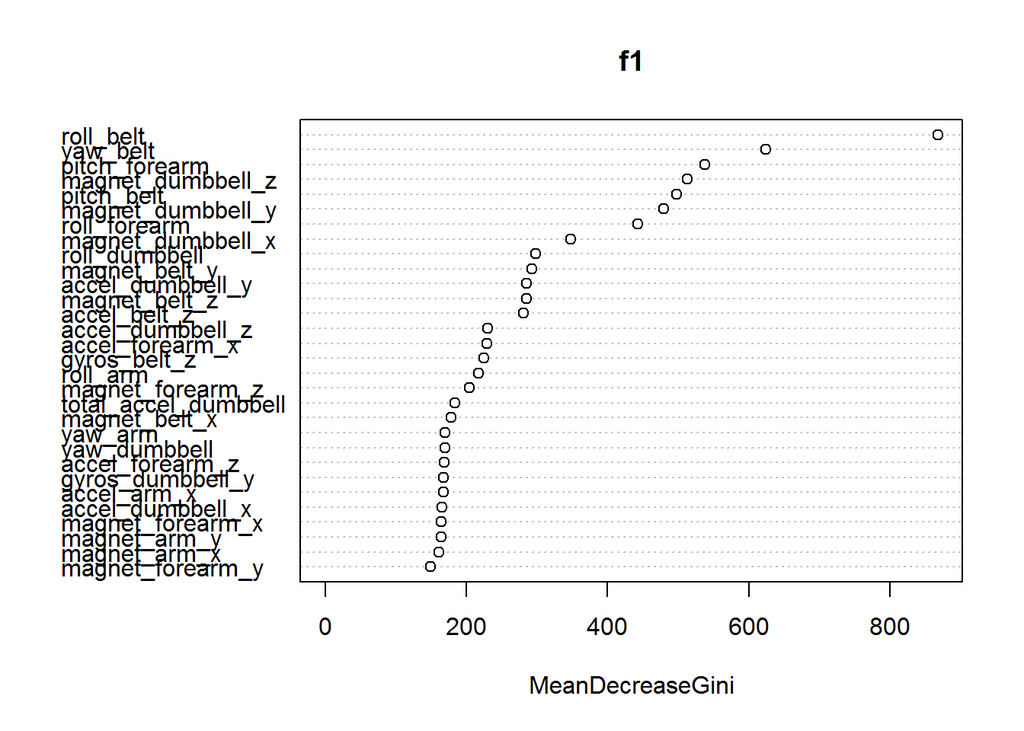

```r
varImpPlot(f1, sort=TRUE)
```

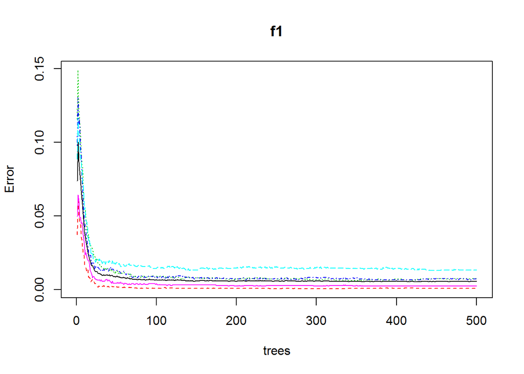

```r
plot(f1)
```